# Exploring the Exponential Distribution

Jake

April 29, 2016

In this assignment we are investigating the exponential distribution by simulating it in R and comparing it with the Central Limit Theorem (CLT). The exponential distribution has these characteristics: Its mean is 1/lambda and the standard deviation is also 1/lambda. We run a thousand simulations (achieved via the R function rexp(n, lambda)) investigating the distribution of averages of 40 exponentials.

To begin, we set the parameters: “n” is the number of exponential samples we are averaging over. “lamda”, described above, is a parameter of the exponential function. “numSims” is the number of simulations, specified in the assignment question. Finally we set the seed for consistancy and reproducibilty.

```r
n <- 40
lamda <- 0.2
numSims <- 1000
set.seed(0)
```

Below we take 40 random samples of of the exponential, take the mean, store it in the vector “meanSimExp” and repeat this 1000 times. We take a histogram of the results.

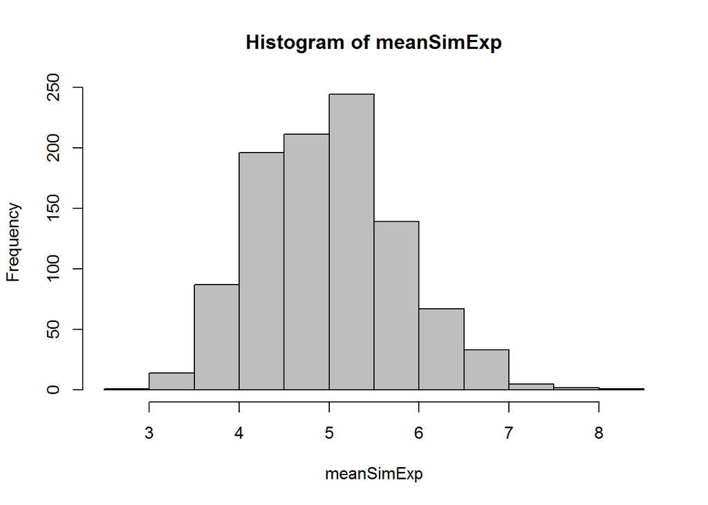

```r
meanSimExp <- NULL
for (i in 1 : numSims) meanSimExp <- c(meanSimExp, mean(rexp(n,lamda)))
hist(meanSimExp, col = "grey")
```

The histogram shows the frequency of the number which results from takking the average of 40 samples of the exponential. What is immediately seen is that the curve “looks” normally distributed with most values grouping around 5 and quickely reducing in frequency either side of 5. In fact we can calculate the mean of the distribution to be 4.9896776 which agrees closely with the theoretical value of 1/lamda = 1/0.2 = 5. It can be shown by running larger number of simulations that the calculated mean converges closer and closer to the theorectical one.

In the next part of the assignment we study the variance of the exponential samples. Running similiar code to that above we can produce a histogram of the variance found in 1000 instances of 40 random samples.

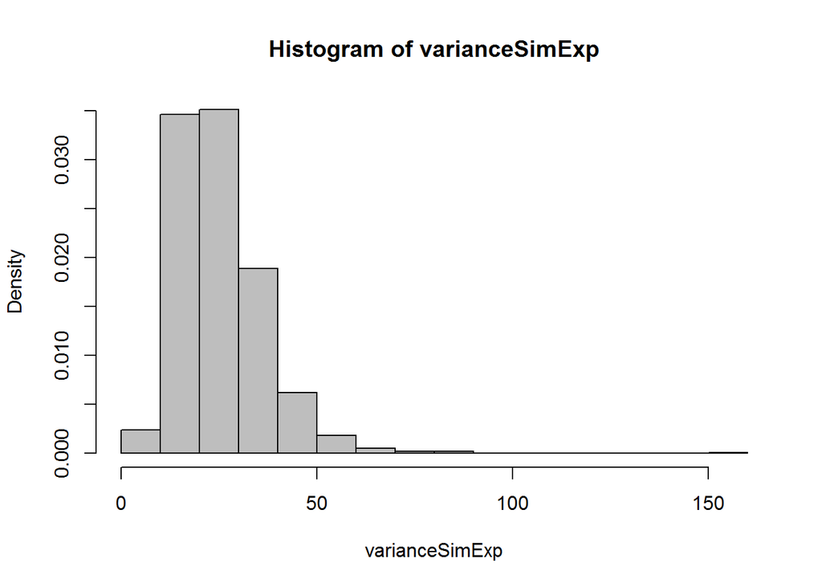

```r
varianceSimExp <- NULL
for (i in 1 : numSims) varianceSimExp <- c(varianceSimExp, var(rexp(n,lamda)))
hist(varianceSimExp, prob=TRUE, col = "grey")
```

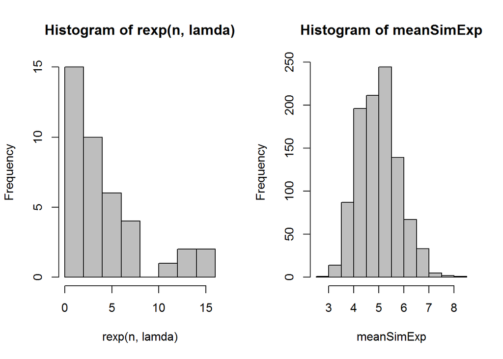

```r
par(mfrow=c(1,2))
hist(rexp(n,lamda), col = "grey")
hist(meanSimExp, col = "grey")
```

```r
#lines(density(meanSimExp), col="blue", lwd=2)
#lines(density(rexp(n,lamda)), col="green", lwd=2)
```